# ICCS datafiles 1999/2009/2016/2022

### Responses Cycle 3 - ICCS2016

[1] “Items: IS3G24A, IS3G24B, IS3G24C, IS3G24D, IS3G24E, IS3G24F, IS3G24G”

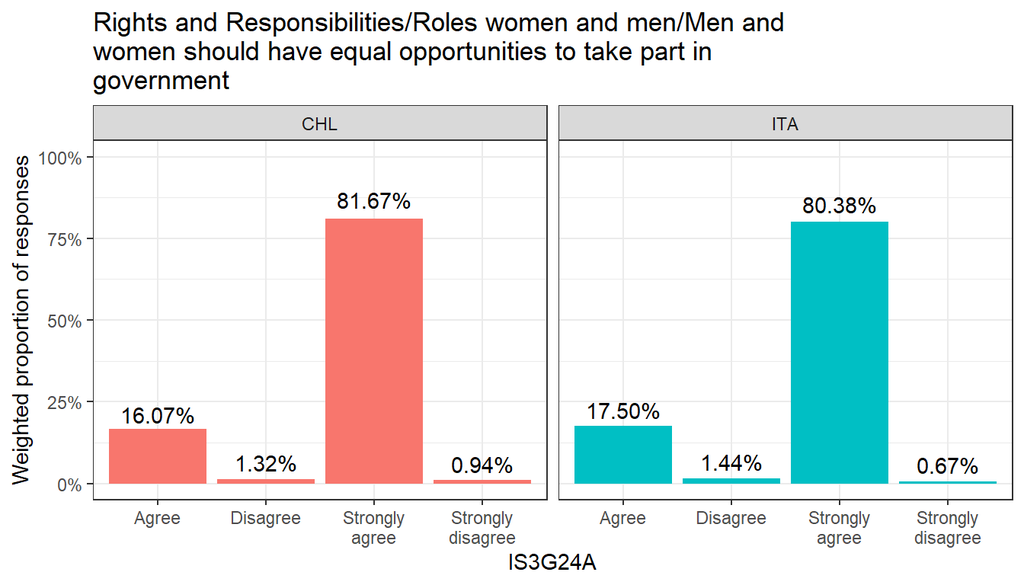

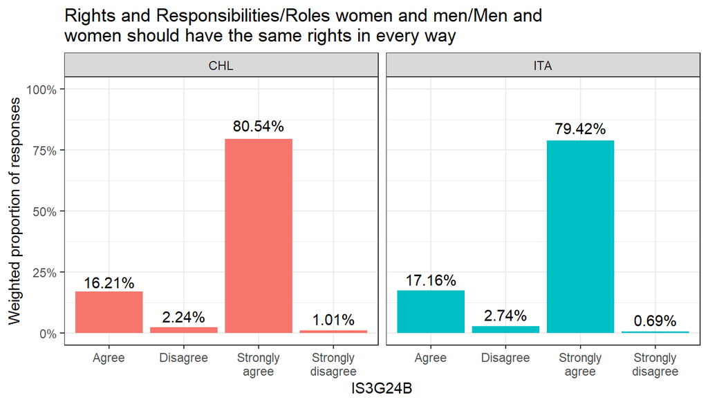

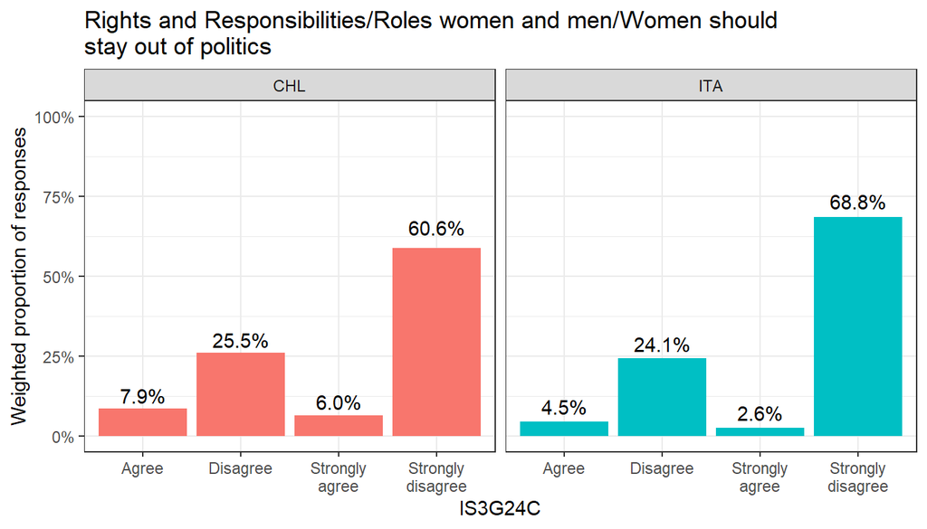

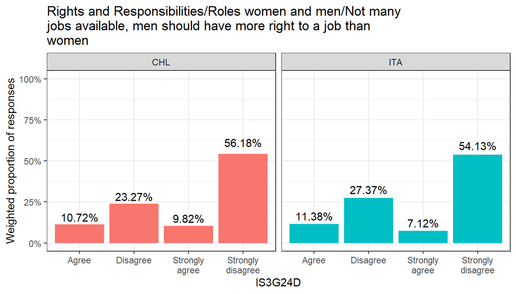

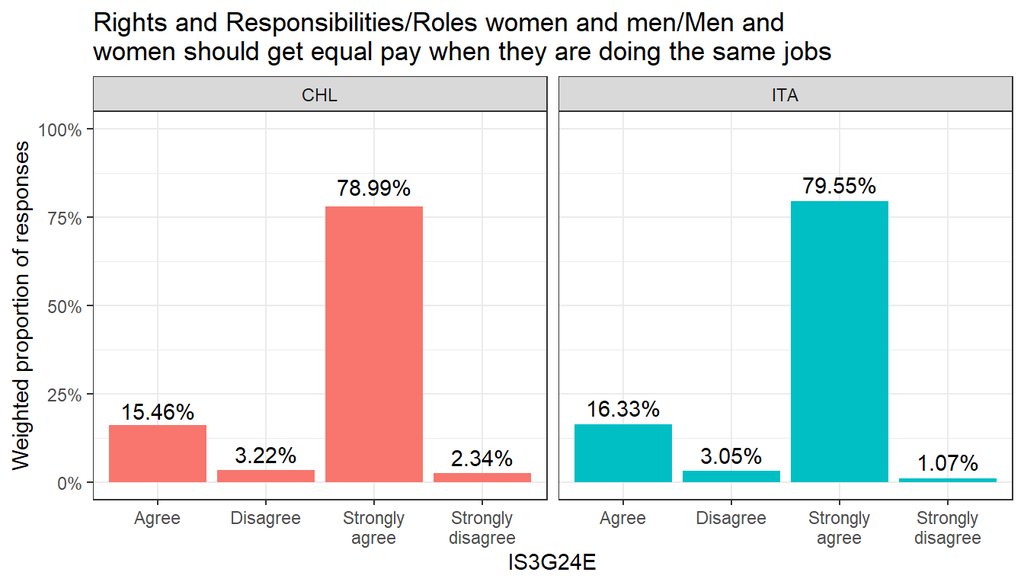

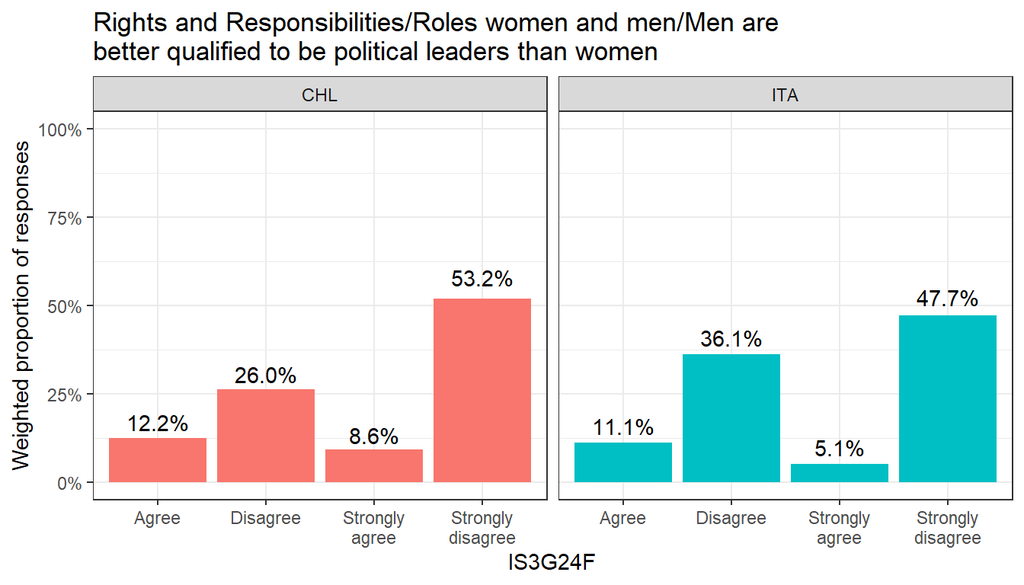

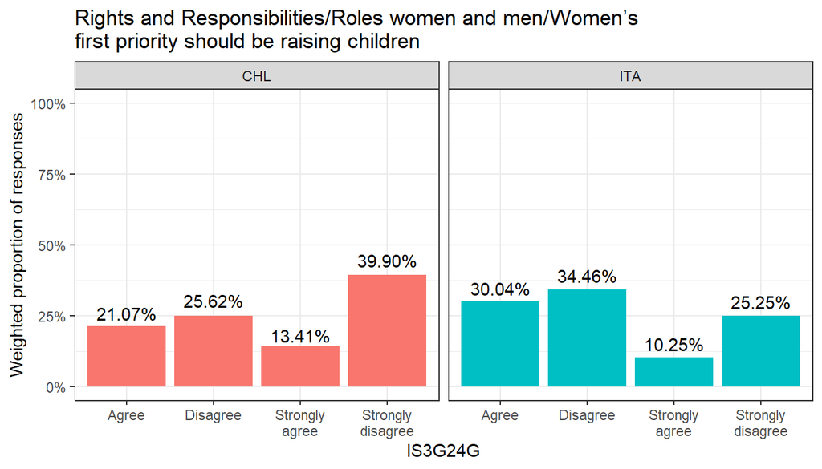

## Construct: Attitudes toward equal rights for all ethnic/racial groups

### Responses Cycle 1 - CivED1999

[1] “Items: BS4G2, BS4G5, BS4G8, BS4G12”

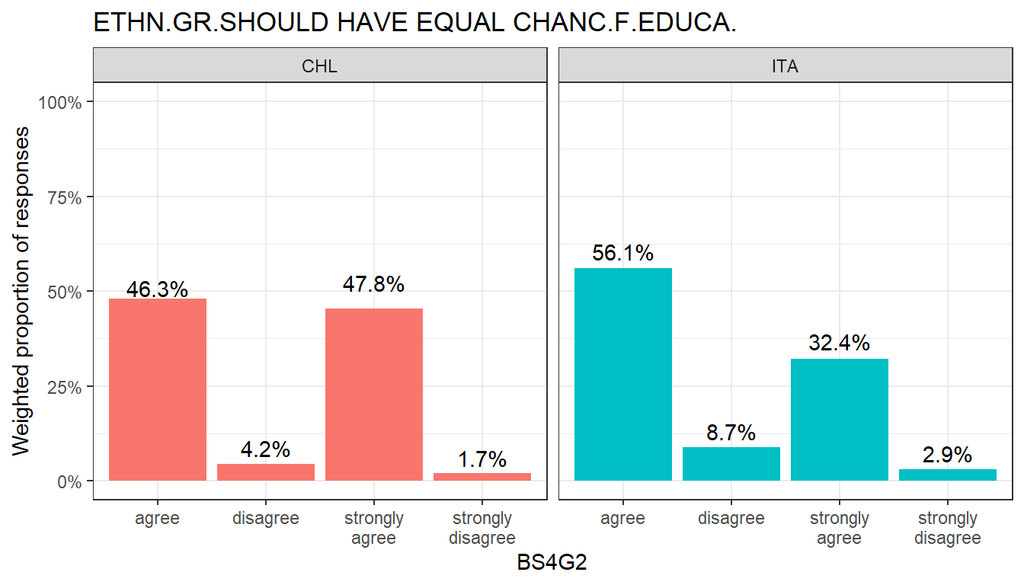

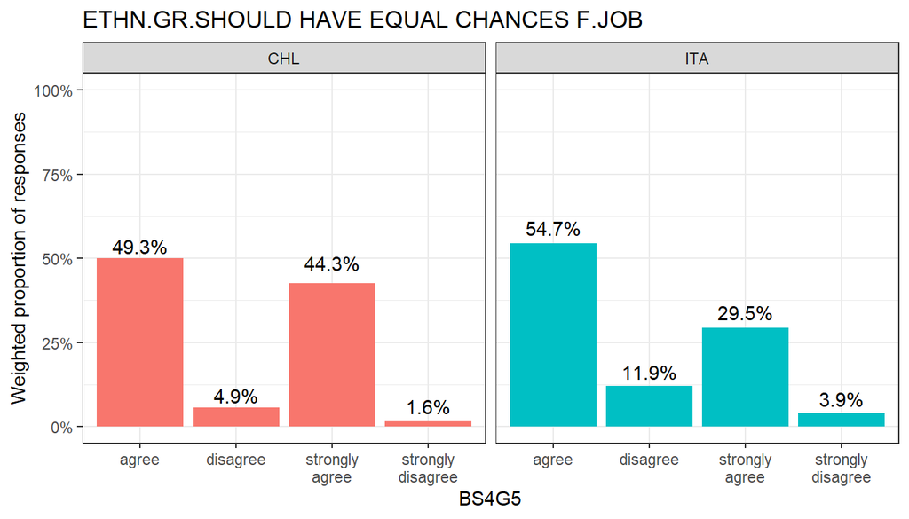

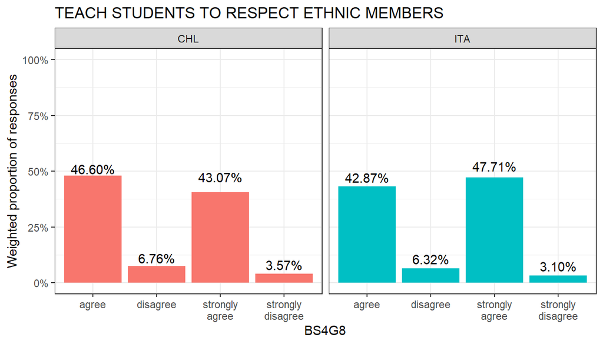

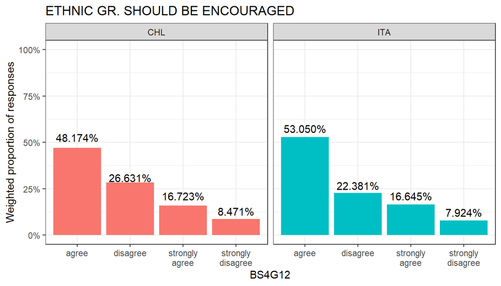

### Responses Cycle 2 - ICCS2009

[1] “Items: IS2P25A, IS2P25B, IS2P25C, IS2P25D, IS2P25E”

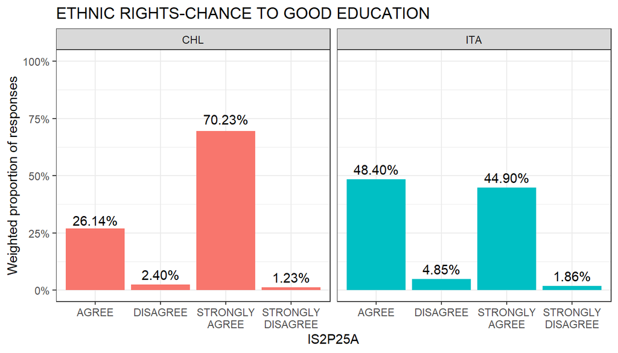

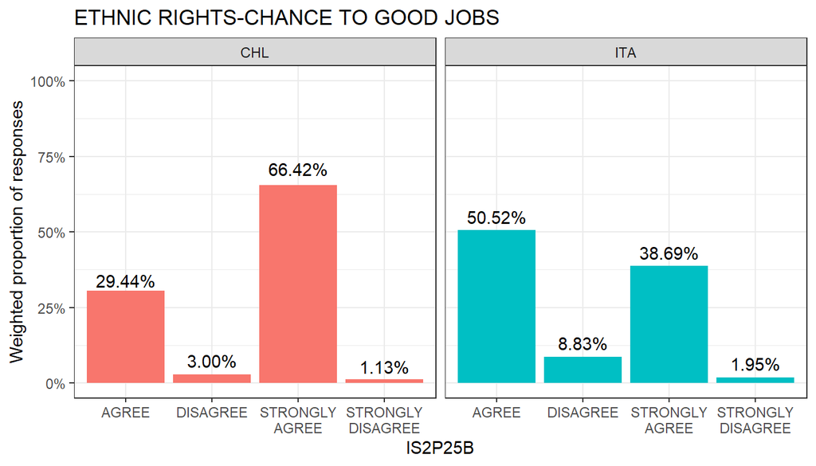

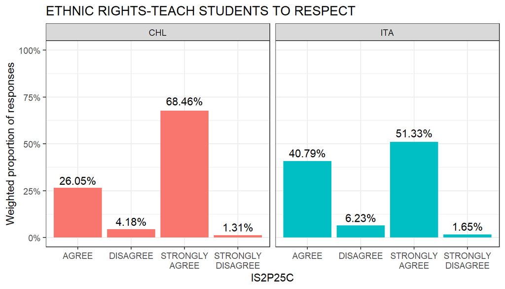

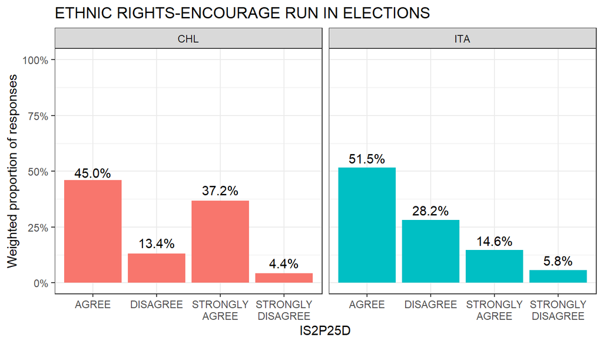

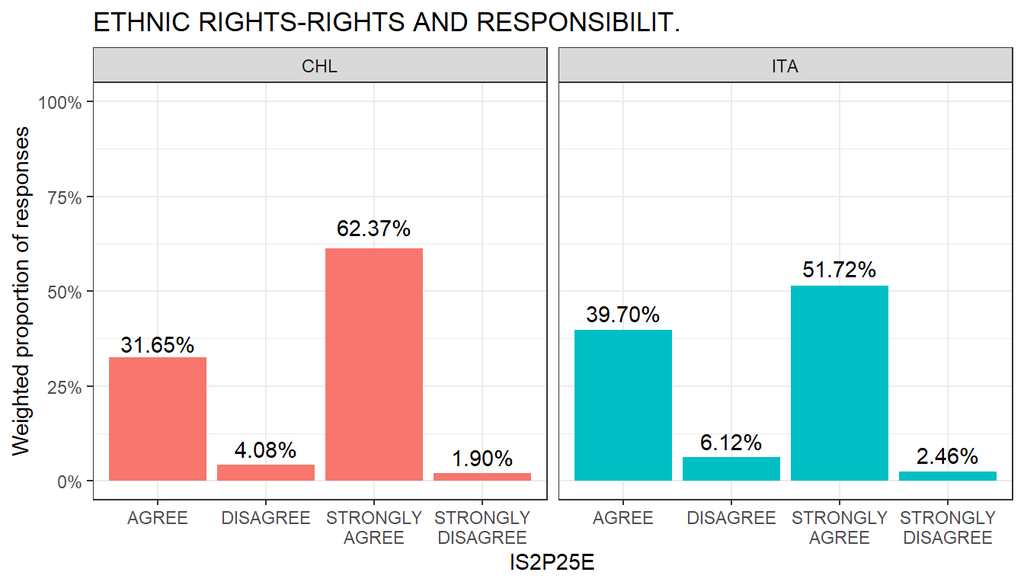

### Responses Cycle 3 - ICCS2016

[1] “Items: IS3G25A, IS3G25B, IS3G25C, IS3G25D, IS3G25E”

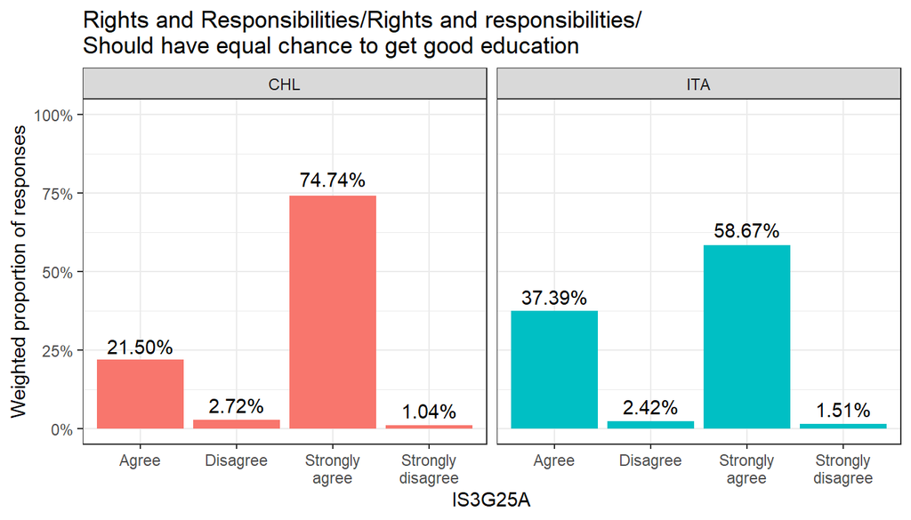

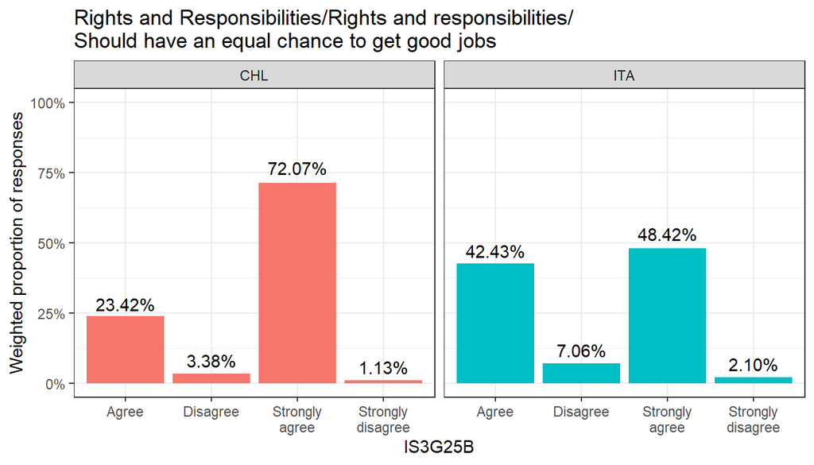

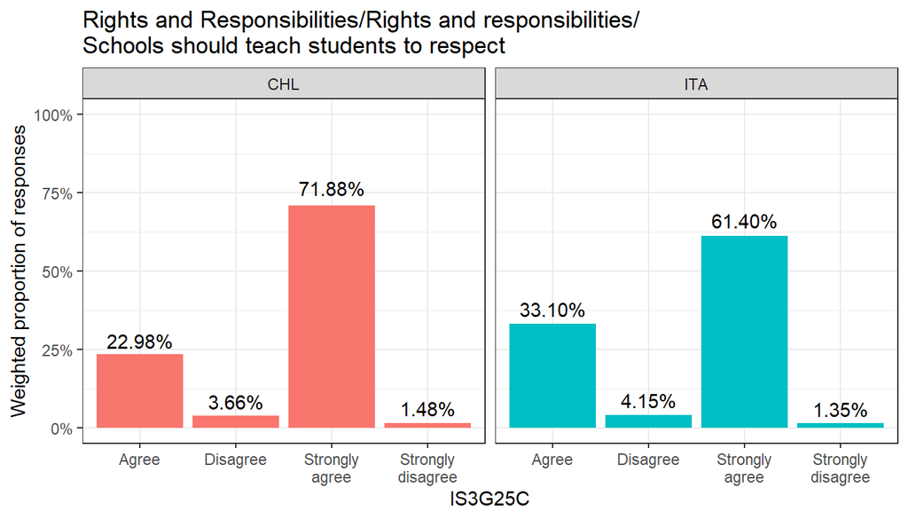

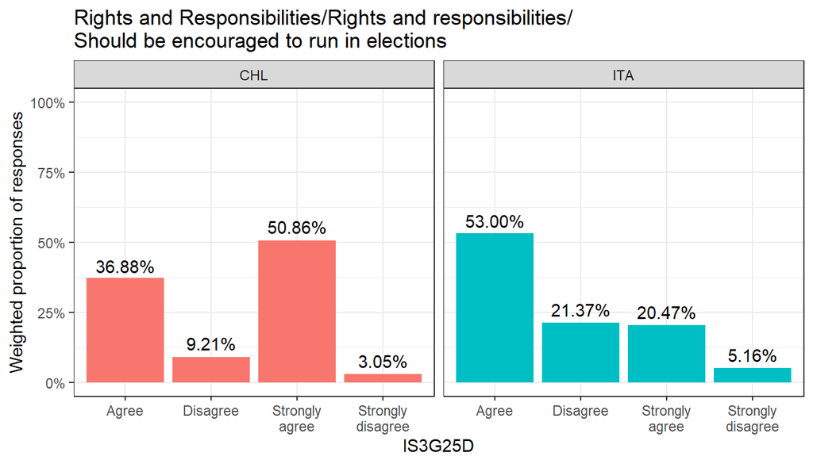

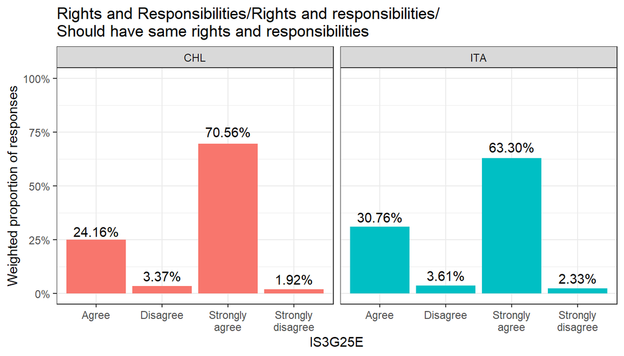

# Confirmatory Factor Analysis (CFA)

# Latent Class Analysis (LCA)